# Longitudinal biomarkers and survival in primary biliary cholangitis: mixed-effects and Cox models of the Mayo Clinic trial

Patricia K. Kamanda

## Background and questions

Between 1974 and 1984 the Mayo Clinic conducted a double-blind, placebo-controlled trial of D-penicillamine in primary biliary cholangitis (PBC, formerly primary biliary cirrhosis), a chronic autoimmune disease of the small bile ducts in the liver. The trial data, with laboratory values recorded at every follow-up visit, are distributed with R’s `survival` package as `pbc` (one row per patient) and `pbcseq` (one row per visit) and have become a standard teaching and methods data set (Fleming and Harrington, 1991; Therneau and Grambsch, 2000). This analysis asks:

1. Did D-penicillamine slow the rise in serum bilirubin over time, the laboratory hallmark of progressive disease?
2. Did D-penicillamine prolong survival?
3. How strongly does bilirubin, measured at baseline and as it changes during follow-up, predict death?

## Data

```r
# Treatment is taken from pbc, where it is documented as 1 = D-penicillamine and 2 = placebo,
# because the coding of trt in pbcseq has differed between versions of the survival package
arm <- pbc |> filter(!is.na(trt)) |>
  transmute(id, treatment = factor(trt, levels = c(2, 1), labels = c("Placebo", "D-penicillamine")))

visits <- pbcseq |>
  select(-trt) |>
  inner_join(arm, by = "id") |>
  mutate(sex       = factor(sex, levels = c("m", "f"), labels = c("Male", "Female")),
         years     = day / 365.25,
         log_bili  = log(bili),
         died      = as.integer(status == 2))

baseline <- visits |> filter(day == 0)
c(patients = n_distinct(visits$id), visits = nrow(visits), baseline_rows = nrow(baseline))
```

```
##      patients        visits baseline_rows
##           312          1945           312
```

Each of the 312 randomized patients contributes a median of 5 visits (range 1 to 16) over a median follow-up of 6.3 years. The outcome status is coded as censored, transplanted, or dead; in the primary analyses liver transplantation is treated as censoring at the date of transplant, which is the convention in the original analyses, and a sensitivity analysis treats it as a competing event.

### Baseline characteristics

```r
summarise_group <- function(d) {
  tibble(
    `Patients`                      = as.character(nrow(d)),
    `Age, years, mean (SD)`         = sprintf("%.1f (%.1f)", mean(d$age), sd(d$age)),
    `Female, n (%)`                 = sprintf("%d (%.0f%%)", sum(d$sex == "Female"), 100 * mean(d$sex == "Female")),
    `Bilirubin, mg/dL, median (IQR)` = sprintf("%.1f (%.1f to %.1f)", median(d$bili), quantile(d$bili, 0.25), quantile(d$bili, 0.75)),
    `Albumin, g/dL, mean (SD)`      = sprintf("%.2f (%.2f)", mean(d$albumin), sd(d$albumin)),
    `Prothrombin time, s, mean (SD)` = sprintf("%.1f (%.1f)", mean(d$protime), sd(d$protime)),
    `Edema present, n (%)`          = sprintf("%d (%.0f%%)", sum(d$edema > 0), 100 * mean(d$edema > 0)),
    `Histologic stage 4, n (%)`     = sprintf("%d (%.0f%%)", sum(d$stage == 4, na.rm = TRUE), 100 * mean(d$stage == 4, na.rm = TRUE)),
    `Deaths during follow-up, n (%)` = sprintf("%d (%.0f%%)", sum(d$status == 2), 100 * mean(d$status == 2)),
    `Transplants, n (%)`            = sprintf("%d (%.0f%%)", sum(d$status == 1), 100 * mean(d$status == 1))
  )
}
table1 <- bind_rows(
  summarise_group(filter(baseline, treatment == "D-penicillamine")),
  summarise_group(filter(baseline, treatment == "Placebo")),
  summarise_group(baseline)
) |>
  mutate(group = c("D-penicillamine", "Placebo", "Overall")) |>
  pivot_longer(-group, names_to = "Characteristic") |>
  pivot_wider(names_from = group, values_from = value)
write.csv(table1, "results/tables/table1_baseline.csv", row.names = FALSE)
table1
```

| Characteristic | D-penicillamine | Placebo | Overall |
| --- | --- | --- | --- |
| Patients | 158 | 154 | 312 |
| Age, years, mean (SD) | 51.4 (11.0) | 48.6 (10.0) | 50.0 (10.6) |
| Female, n (%) | 137 (87%) | 139 (90%) | 276 (88%) |
| Bilirubin, mg/dL, median (IQR) | 1.4 (0.8 to 3.2) | 1.3 (0.7 to 3.6) | 1.4 (0.8 to 3.4) |
| Albumin, g/dL, mean (SD) | 3.52 (0.44) | 3.52 (0.40) | 3.52 (0.42) |
| Prothrombin time, s, mean (SD) | 10.7 (0.9) | 10.8 (1.0) | 10.7 (0.9) |
| Edema present, n (%) | 31 (20%) | 34 (22%) | 65 (21%) |
| Histologic stage 4, n (%) | 55 (35%) | 54 (35%) | 109 (35%) |
| Deaths during follow-up, n (%) | 71 (45%) | 69 (45%) | 140 (45%) |
| Transplants, n (%) | 12 (8%) | 17 (11%) | 29 (9%) |

Randomization produced broadly balanced groups; patients on D-penicillamine were on average about three years older, and age is adjusted for in every model. Bilirubin is strongly right-skewed, so it is analyzed on the log scale throughout.

## Question 1: bilirubin trajectories

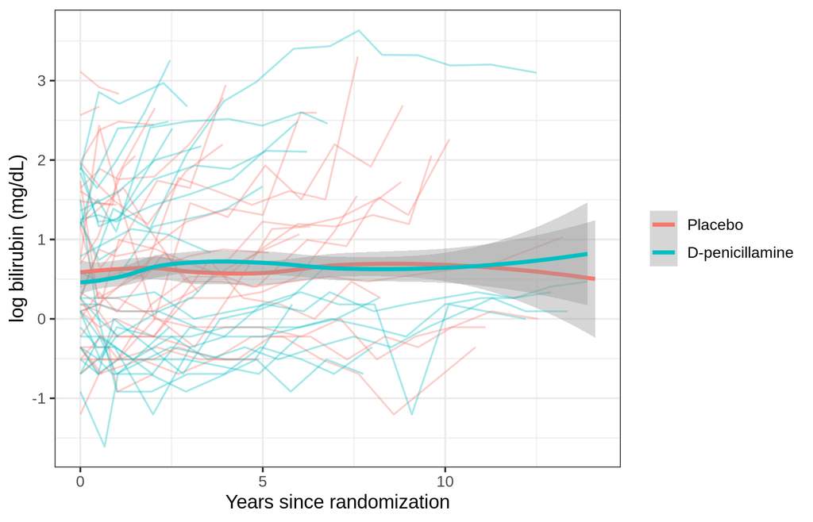

Log bilirubin over follow-up for a random sample of 60 patients, with a smoothed mean for each arm.

```r
sampled <- sample(unique(visits$id), 60)
ggplot(visits, aes(years, log_bili, colour = treatment)) +
  geom_line(data = filter(visits, id %in% sampled), aes(group = id), alpha = 0.35) +
  geom_smooth(method = "loess", se = TRUE, linewidth = 1.2, span = 0.75) +
  labs(x = "Years since randomization", y = "log bilirubin (mg/dL)", colour = NULL)
```

```r
fit_lmm <- lmer(log_bili ~ years * treatment + age + sex + (years | id), data = visits, REML = TRUE)
lmm_table <- tidy(fit_lmm, effects = "fixed", conf.int = TRUE) |>
  select(term, estimate, std.error, df, statistic, p.value, conf.low, conf.high)
write.csv(lmm_table, "results/tables/lmm_log_bilirubin.csv", row.names = FALSE)
lmm_table |> mutate(across(where(is.numeric), ~ round(.x, 4)))
```

| term | estimate | std.error | df | statistic | p.value | conf.low | conf.high |
| --- | --- | --- | --- | --- | --- | --- | --- |
| (Intercept) | 0.7393 | 0.3489 | 279.0247 | 2.1189 | 0.0350 | 0.0525 | 1.4260 |
| years | 0.1794 | 0.0178 | 163.2597 | 10.0728 | 0.0000 | 0.1442 | 0.2146 |
| treatmentD-penicillamine | -0.1407 | 0.1171 | 302.5218 | -1.2019 | 0.2304 | -0.3712 | 0.0897 |
| age | 0.0001 | 0.0055 | 285.5554 | 0.0243 | 0.9806 | -0.0107 | 0.0110 |
| sexFemale | -0.2023 | 0.1798 | 274.7731 | -1.1254 | 0.2614 | -0.5562 | 0.1516 |
| years:treatmentD-penicillamine | -0.0044 | 0.0249 | 161.8310 | -0.1779 | 0.8590 | -0.0536 | 0.0447 |

```r
VarCorr(fit_lmm)
```

```
##  Groups   Name        Std.Dev. Corr
##  id       (Intercept) 0.99790
##           years       0.17187  0.408
##  Residual             0.34902
```

On the placebo arm, log bilirubin rises by 0.179 per year, which is about 20% per year on the original scale. The difference in slope on D-penicillamine is -0.004 per year (95% CI -0.054 to 0.045, p = 0.859), so there is no evidence that the drug slowed the rise in bilirubin.

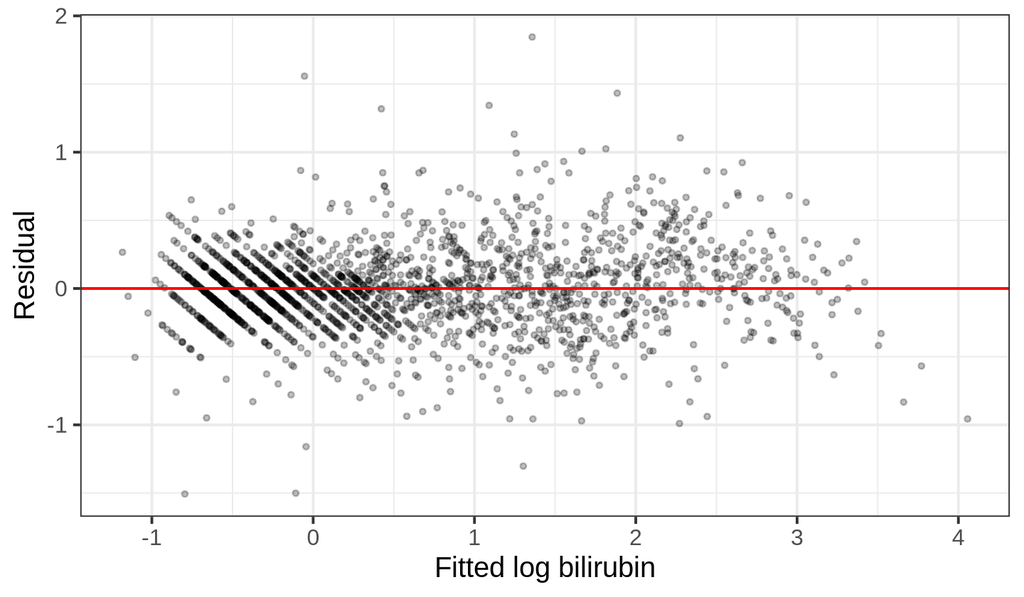

Model checks: residuals against fitted values, and the distribution of estimated patient-specific slopes.

```r
checks <- data.frame(fitted = fitted(fit_lmm), residual = resid(fit_lmm))
p1 <- ggplot(checks, aes(fitted, residual)) + geom_point(alpha = 0.25, size = 0.8) +
  geom_hline(yintercept = 0, colour = "red") + labs(x = "Fitted log bilirubin", y = "Residual")
slopes <- coef(fit_lmm)$id |> mutate(slope = years)
p2 <- ggplot(slopes, aes(slope)) + geom_histogram(bins = 30, fill = "#2471A3", colour = "white") +
  labs(x = "Patient-specific slope (log bilirubin per year)", y = "Patients")
print(p1)
```

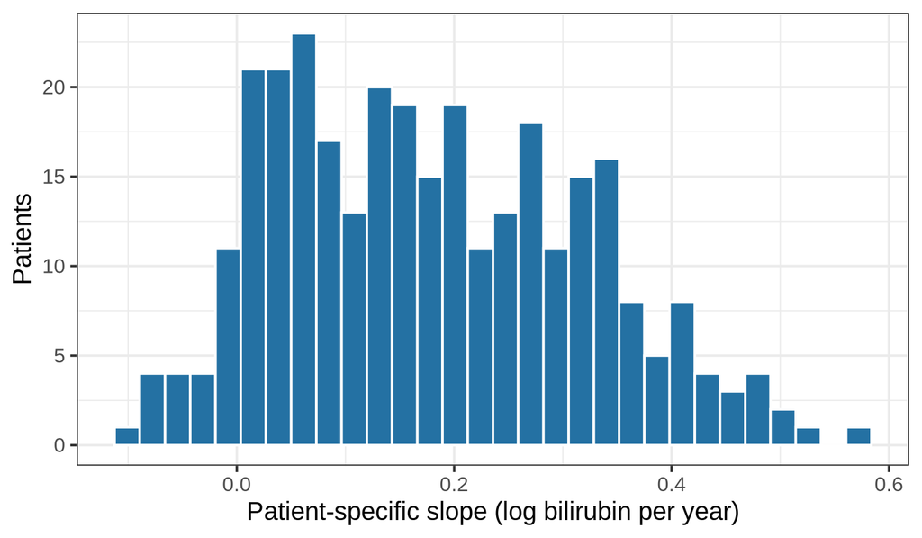

Model checks: residuals against fitted values, and the distribution of estimated patient-specific slopes.

```r
print(p2)
```

## Question 2: survival by treatment arm

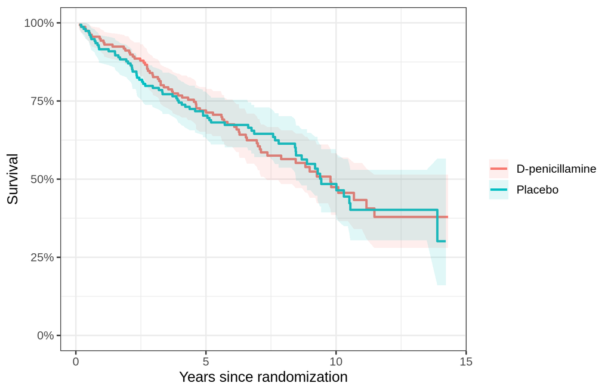

Kaplan-Meier estimates of survival free of death, with transplantation treated as censoring.

```r
km <- survfit(Surv(futime / 365.25, died) ~ treatment, data = baseline)
km_data <- tidy(km) |> mutate(strata = sub("treatment=", "", strata))
ggplot(km_data, aes(time, estimate, colour = strata, fill = strata)) +
  geom_step(linewidth = 0.9) +
  geom_ribbon(aes(ymin = conf.low, ymax = conf.high), alpha = 0.12, colour = NA, stat = "identity") +
  scale_y_continuous(limits = c(0, 1), labels = scales::percent) +
  labs(x = "Years since randomization", y = "Survival", colour = NULL, fill = NULL)
```

```r
logrank <- survdiff(Surv(futime, died) ~ treatment, data = baseline)
p_logrank <- pchisq(logrank$chisq, df = 1, lower.tail = FALSE)
summary(km, times = c(5, 10))$table
```

```
##                           records n.max n.start events    rmean se(rmean)
## treatment=Placebo             154   154     154     69 8.976063 0.4567284
## treatment=D-penicillamine     158   158     158     71 9.011265 0.4442183
##                             median  0.95LCL 0.95UCL
## treatment=Placebo         9.431896 8.459959      NA
## treatment=D-penicillamine 9.785079 7.362081      NA
```

The log-rank test gives p = 0.992.

```r
cox_trt <- coxph(Surv(futime, died) ~ treatment, data = baseline)
cox_trt_tab <- tidy(cox_trt, exponentiate = TRUE, conf.int = TRUE)
cox_trt_tab
```

| term | estimate | std.error | statistic | p.value | conf.low | conf.high |
| --- | --- | --- | --- | --- | --- | --- |
| treatmentD-penicillamine | 0.9983373 | 0.1691051 | -0.0098408 | 0.9921483 | 0.7166957 | 1.390656 |

The hazard ratio for death on D-penicillamine against placebo is 1 (95% CI 0.72 to 1.39), in agreement with the trial’s published conclusion that the drug conferred no survival benefit.

## Question 3: bilirubin as a predictor of death

### Baseline prognostic model

The covariates are those of the Mayo risk score: age, log bilirubin, log albumin, log prothrombin time, and edema, with treatment retained as a design variable.

```r
cox_base <- coxph(Surv(futime, died) ~ treatment + age + log(bili) + log(albumin) + log(protime) + edema,
                  data = baseline)
cox_base_tab <- tidy(cox_base, exponentiate = TRUE, conf.int = TRUE) |>
  select(term, estimate, conf.low, conf.high, p.value)
write.csv(cox_base_tab, "results/tables/cox_baseline_mayo_covariates.csv", row.names = FALSE)
cox_base_tab |> mutate(across(where(is.numeric), ~ signif(.x, 3)))
```

| term | estimate | conf.low | conf.high | p.value |
| --- | --- | --- | --- | --- |
| treatmentD-penicillamine | 0.8810 | 0.6260 | 1.24 | 4.70e-01 |
| age | 1.0400 | 1.0200 | 1.06 | 1.40e-06 |
| log(bili) | 2.3500 | 1.9300 | 2.85 | 0.00e+00 |
| log(albumin) | 0.0875 | 0.0212 | 0.36 | 7.44e-04 |
| log(protime) | 72.9000 | 9.3900 | 565.00 | 4.09e-05 |
| edema | 1.7900 | 1.0500 | 3.07 | 3.26e-02 |

```r
c(concordance = unname(round(cox_base$concordance["concordance"], 3)))
```

```
## concordance
##       0.838
```

```r
zph <- cox.zph(cox_base)
zph
```

```
##                chisq df      p
## treatment    0.30434  1 0.5812
## age          0.06610  1 0.7971
## log(bili)    0.00613  1 0.9376
## log(albumin) 2.93552  1 0.0867
## log(protime) 2.35873  1 0.1246
## edema        6.97303  1 0.0083
## GLOBAL       9.92105  6 0.1280
```

### Time-dependent Cox model with updated bilirubin

Baseline bilirubin uses only the first measurement. A time-dependent Cox model instead lets each patient’s hazard at any moment depend on their most recent bilirubin, albumin, and prothrombin time. The data are restructured into counting-process form with `tmerge`, so that each interval between visits carries the values measured at its start.

```r
td <- tmerge(baseline |> select(id, futime, died, treatment, age, sex),
             baseline |> select(id, futime, died),
             id = id, death = event(futime, died))
td <- tmerge(td, visits, id = id,
             bili = tdc(day, bili), albumin = tdc(day, albumin), protime = tdc(day, protime),
             edema = tdc(day, edema))
c(intervals = nrow(td), patients = n_distinct(td$id), deaths = sum(td$death))
```

```
## intervals  patients    deaths
##      1945       312       140
```

```r
cox_td <- coxph(Surv(tstart, tstop, death) ~ treatment + age + log(bili) + log(albumin) + log(protime) + edema,
                data = td)
cox_td_tab <- tidy(cox_td, exponentiate = TRUE, conf.int = TRUE) |>
  select(term, estimate, conf.low, conf.high, p.value)
write.csv(cox_td_tab, "results/tables/cox_time_dependent.csv", row.names = FALSE)
cox_td_tab |> mutate(across(where(is.numeric), ~ signif(.x, 3)))
```

| term | estimate | conf.low | conf.high | p.value |
| --- | --- | --- | --- | --- |
| treatmentD-penicillamine | 0.9450 | 0.66300 | 1.3500 | 7.52e-01 |
| age | 1.0500 | 1.03000 | 1.0700 | 3.00e-07 |
| log(bili) | 2.9600 | 2.38000 | 3.6800 | 0.00e+00 |
| log(albumin) | 0.0244 | 0.00925 | 0.0644 | 0.00e+00 |
| log(protime) | 17.2000 | 4.96000 | 59.4000 | 7.20e-06 |
| edema | 2.2600 | 1.43000 | 3.5700 | 5.10e-04 |

```r
c(concordance = unname(round(cox_td$concordance["concordance"], 3)))
```

```
## concordance
##       0.908
```

With bilirubin updated at every visit, the hazard ratio per unit of log bilirubin is 2.96 (95% CI 2.38 to 3.68), and the concordance rises from 0.84 to 0.91. A patient’s current bilirubin is therefore a stronger guide to their immediate risk than the value recorded when they entered the trial.

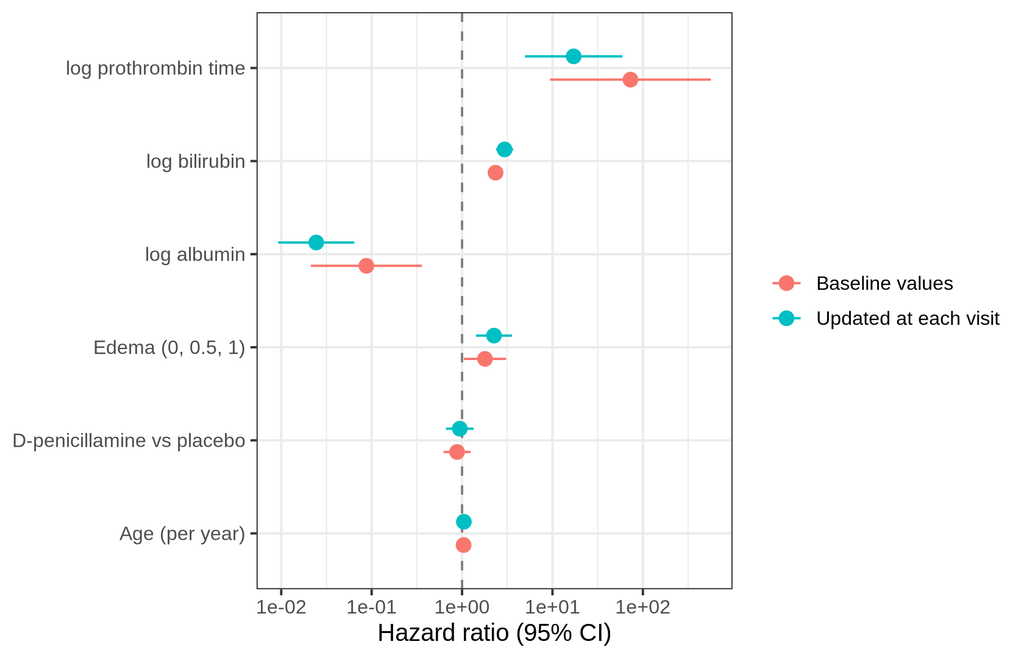

Hazard ratios from the baseline and time-dependent Cox models (log scale).

```r
hr_both <- bind_rows(mutate(cox_base_tab, model = "Baseline values"),
                     mutate(cox_td_tab, model = "Updated at each visit")) |>
  mutate(term = recode(term, "treatmentD-penicillamine" = "D-penicillamine vs placebo", "age" = "Age (per year)",
                       "log(bili)" = "log bilirubin", "log(albumin)" = "log albumin",
                       "log(protime)" = "log prothrombin time", "edema" = "Edema (0, 0.5, 1)"))
ggplot(hr_both, aes(estimate, term, colour = model)) +
  geom_vline(xintercept = 1, linetype = 2, colour = "grey50") +
  geom_pointrange(aes(xmin = conf.low, xmax = conf.high), position = position_dodge(width = 0.5)) +
  scale_x_log10() + labs(x = "Hazard ratio (95% CI)", y = NULL, colour = NULL)
```

### Sensitivity analysis: transplantation as a competing event

Treating transplant as censoring assumes that transplanted patients would have had the same subsequent risk of death as those who remained, which is unlikely, since transplant was offered to the sickest patients. Fine and Gray regression treats transplant instead as a competing event.

```r
baseline_cr <- baseline |> mutate(event = factor(status, levels = 0:2, labels = c("censored", "transplant", "death")))
fg_data <- finegray(Surv(futime, event) ~ ., data = baseline_cr, etype = "death")
fg <- coxph(Surv(fgstart, fgstop, fgstatus) ~ treatment + age + log(bili) + log(albumin) + log(protime) + edema,
            data = fg_data, weights = fgwt)
fg_tab <- tidy(fg, exponentiate = TRUE, conf.int = TRUE) |> select(term, estimate, conf.low, conf.high, p.value)
write.csv(fg_tab, "results/tables/finegray_death.csv", row.names = FALSE)
fg_tab |> mutate(across(where(is.numeric), ~ signif(.x, 3)))
```

| term | estimate | conf.low | conf.high | p.value |
| --- | --- | --- | --- | --- |
| treatmentD-penicillamine | 0.890 | 0.6180 | 1.280 | 5.30e-01 |
| age | 1.050 | 1.0300 | 1.070 | 7.40e-06 |
| log(bili) | 2.150 | 1.7800 | 2.600 | 0.00e+00 |
| log(albumin) | 0.111 | 0.0339 | 0.363 | 2.79e-04 |
| log(protime) | 144.000 | 21.2000 | 983.000 | 4.00e-07 |
| edema | 1.970 | 0.9540 | 4.090 | 6.68e-02 |

The subdistribution hazard ratios are close to the cause-specific estimates, so the conclusions do not depend on how the 29 transplants are handled.

## Conclusions

In this trial D-penicillamine neither slowed the rise in bilirubin nor improved survival. Bilirubin was the dominant predictor of death, and modelling it as a time-varying quantity, rather than a single baseline value, gave a stronger and more clinically useful account of each patient’s changing risk. The same toolkit (mixed models for irregularly measured biomarkers, Kaplan-Meier and Cox models for time to event, counting-process data for time-dependent covariates, and competing-risks sensitivity analyses) applies directly to observational cohorts built from electronic health records.

## References

Fleming, T. R., & Harrington, D. P. (1991). *Counting processes and survival analysis*. Wiley.

Therneau, T. M., & Grambsch, P. M. (2000). *Modeling survival data: Extending the Cox model*. Springer.